# *igblastr* overview

Hervé Pagès, Kellie MacPhee and Ollivier Hyrien

Fred Hutch Cancer Center, Seattle, WA

Compiled 17 April 2025; Modified 17 April 2025

#### Package

igblastr 0.99.0

# 1 Introduction

The Immunoglobulin Basic Local Alignment Search Tool (IgBLAST) is a specialized bioinformatics tool developed by the National Center for Biotechnology Information (NCBI) for the analysis of B-cell receptor (BCR) and T-cell receptor (TCR) sequences (Ye et al., 2013). IgBLAST performs sequence alignment and annotation, with key outputs including germline V, D, and J gene assignments; detection of somatic hypermutations introduced during affinity maturation; identification and annotation of complementarity-determining regions (CDR1–CDR3) and framework regions (FR1–FR4); and both nucleotide and protein-level alignments.

*igblastr* is an R/Bioconductor package that provides functions to conveniently install and run a local IgBLAST installation from within R. The package is designed to make it as easy as possible to use IgBLAST in R by streamlining the installation of both IgBLAST and its associated germline databases. In particular, these installations can be performed with a single function call, do not require root access, and persist across R sessions.

The main function in the package is `igblastn()`, a wrapper to the `igblastn` *standalone executable* included in IgBLAST. In addition to `igblastn()`, the package provides:

- A function (`install_igblast()`) for conveniently downloading and installing a pre-compiled IgBLAST from NCBI.
- Functions to download and install germline databases from the IMGT/V-QUEST download site, and to configure them for use with `igblastn()`.
- A set of built-in germline databases from OGRDB, the AIRR Community’s Open Germline Reference Database.
- A set of built-in constant region (C-region) databases (a.k.a. constant region databases) from IMGT/V-QUEST.
- Utility functions to parse the results returned by `igblastn()`.
- Utility functions to download data from OAS, the Observed Antibody Space database, and prepare it for use with IgBLAST.
- Etc.

IgBLAST is described at https://pubmed.ncbi.nlm.nih.gov/23671333/

Online IgBLAST: https://www.ncbi.nlm.nih.gov/igblast/

Please use https://github.com/HyrienLab/igblastr/issues to report bugs, provide feedback, request features (etc) about *igblastr*.

# 2 Install and load the package

Like any Bioconductor package, *igblastr* should be installed with `BiocManager::install()`:

```r
if (!require("BiocManager", quietly=TRUE))
    install.packages("BiocManager")
BiocManager::install("igblastr")
```

`BiocManager::install()` will take care of installing the package dependencies that are missing.

Load the package:

```r
library(igblastr)
```

# 3 Install IgBLAST

If IgBLAST is already installed on your system, you can tell *igblastr* to use it by setting the environment variable `IGBLAST_ROOT` to the path of your IgBLAST installation. See `?IGBLAST_ROOT` for more information.

Otherwise, simply call `install_igblast()` to install the latest version of IgBLAST. As of March 2025, NCBI provides pre-compiled versions of IgBLAST for Linux, Windows, Intel Mac and Mac Silicon. `install_igblast()` will automatically download the appropriate pre-compiled version of IgBLAST for your platform from the NCBI FTP site, and install it in a location that will be remembered across R sessions.

```r
if (!has_igblast())
    install_igblast()
```

See `?install_igblast` for more information.

Note that we use `has_igblast()` to avoid reinstalling IgBLAST if *igblastr* already has access to a working IgBLAST installation.

Display basic information about the IgBLAST installation used by *igblastr*:

```r
igblast_info()
```

```
## igblast_root: /home/hpages/.cache/R/igblastr/igblast_roots/1.22.0
## Version: 1.22.0
## OS/arch: Linux/x86_64
## Build: igblast 1.22.0, build Oct 11 2023 16:06:20
## organisms: human, mouse, rabbit, rat, rhesus_monkey
```

# 4 Install and select a germline database

The *igblastr* package includes a FASTA file containing 8,437 paired heavy and light chain human antibody sequences (16,874 individual sequences) retrieved from OAS. These sequences will serve as our *query sequences*, that is, the immunoglobulin (Ig) sequences that we will analyze in this vignette.

Before we can do so, the `igblastn` *standalone executable* in IgBLAST (and, by extension, our `igblastn()` function) needs access to the germline V, D, and J gene sequences for humans. Before `igblastn` can use them, these germline sequences must first be stored in three separate BLAST databases. We will refer to these as the V-region, D-region, and J-region databases, respectively. When considered together, we will refer to them as the *germline database*.

## 4.1 Built-in germline databases

The *igblastr* package includes a set of built-in germline databases for human and mouse that were obtained from the OGRDB database (AIRR community). These can be listed with:

```r
list_germline_dbs(builtin.only=TRUE)
```

```
##  db_name                                   IGHV IGHD IGHJ IGKV IGKJ IGLV IGLJ
##  _AIRR.human.IGH+IGK+IGL.202501             205   33    7   69    7   80   10
##  _AIRR.mouse.CAST_EiJ.IGH+IGK+IGL.202501     87    9    4   88   11    9    7
##  _AIRR.mouse.LEWES_EiJ.IGH+IGK+IGL.202501    78   11    4   87   11    4    7
##  _AIRR.mouse.MSM_MsJ.IGH+IGK+IGL.202501      84    9    4   83   11    5    7
##  _AIRR.mouse.NOD_ShiLtJ.IGH+IGK+IGL.202501   84    9    4   62   11    3    7
##  _AIRR.mouse.PWD_PhJ.IGH+IGK+IGL.202501      92   10    4   89   11    3    7
```

The last part of the database name indicates the date of the download in YYYYMM format.

If our query sequences are from humans or from one of the mouse strains listed above, we can already select the appropriate database with `use_germline_db()` and skip the subsection below.

## 4.2 Install additional germline databases

AIRR/OGRDB and IMGT/V-QUEST are two providers of germline databases that can be used with IgBLAST. If, for any reason, none of the built-in AIRR/OGRDB germline databases is suitable (e.g., if your query sequences are not from human or mouse), you can use `install_IMGT_germline_db()` to install additional germline databases. Below, we show how to install the latest human germline database from IMGT/V-QUEST.

First, we list the most recent IMGT/V-QUEST releases:

```r
head(list_IMGT_releases())
```

```
## [1] "202506-1" "202449-1" "202430-2" "202416-4" "202405-2" "202349-3"
```

The organisms included in release 202506-1 are:

```r
list_IMGT_organisms("202506-1")
```

```
##  [1] "Aotus_nancymaae"          "Bos_taurus"
##  [3] "Camelus_dromedarius"      "Canis_lupus_familiaris"
##  [5] "Capra_hircus"             "Chondrichthyes"
##  [7] "Danio_rerio"              "Equus_caballus"
##  [9] "Felis_catus"              "Gadus_morhua"
## [11] "Gallus_gallus"            "Gorilla_gorilla_gorilla"
## [13] "Heterocephalus_glaber"    "Homo_sapiens"
## [15] "Ictalurus_punctatus"      "Lemur_catta"
## [17] "Macaca_fascicularis"      "Macaca_mulatta"
## [19] "Mus_musculus"             "Mus_musculus_C57BL6J"
## [21] "Mustela_putorius_furo"    "Neogale_vison"
## [23] "Nonhuman_primates"        "Oncorhynchus_mykiss"
## [25] "Ornithorhynchus_anatinus" "Oryctolagus_cuniculus"
## [27] "Ovis_aries"               "Pongo_abelii"
## [29] "Pongo_pygmaeus"           "Rattus_norvegicus"
## [31] "Salmo_salar"              "Sus_scrofa"
## [33] "Teleostei"                "Tursiops_truncatus"
## [35] "Vicugna_pacos"
```

Next, we install the human germline database from the latest IMGT/V-QUEST release:

```r
install_IMGT_germline_db("202506-1", organism="Homo sapiens", force=TRUE)
```

See `?install_IMGT_germline_db` for more information.

Finally, we select the newly installed germline database for use with `igblastn()`:

```r
use_germline_db("IMGT-202506-1.Homo_sapiens.IGH+IGK+IGL")
```

See `?use_germline_db` for more information.

## 4.3 Display the full list of local germline dbs

To see the full list of local germline dbs:

```r
list_germline_dbs()
```

```
##  db_name                                   IGHV IGHD IGHJ IGKV IGKJ IGLV IGLJ
##  _AIRR.human.IGH+IGK+IGL.202501             205   33    7   69    7   80   10
##  _AIRR.mouse.CAST_EiJ.IGH+IGK+IGL.202501     87    9    4   88   11    9    7
##  _AIRR.mouse.LEWES_EiJ.IGH+IGK+IGL.202501    78   11    4   87   11    4    7
##  _AIRR.mouse.MSM_MsJ.IGH+IGK+IGL.202501      84    9    4   83   11    5    7
##  _AIRR.mouse.NOD_ShiLtJ.IGH+IGK+IGL.202501   84    9    4   62   11    3    7
##  _AIRR.mouse.PWD_PhJ.IGH+IGK+IGL.202501      92   10    4   89   11    3    7
##  IMGT-202506-1.Homo_sapiens.IGH+IGK+IGL     460   47   15  126    9  114   10 *
##  IMGT-202506-1.Mus_musculus.IGH+IGK+IGL     675   61    9  168   10   19    8
```

Note that the asterisk (`*`) displayed at the far right of the output from `list_germline_dbs()` indicates the currently selected germline database (you may need to scroll horizontally to see the asterisk).

See `?list_germline_dbs` for more information.

# 5 Select a constant region database (optional)

The `igblastn` *standalone executable* in IgBLAST can also use constant region (C region) sequences to improve the analysis. As with the germline V, D, and J gene sequences, the C-region sequences should typically come from the same organism as the query sequences, and they must also be formatted as a BLAST database. We will refer to this database as the C-region database.

The *igblastr* package includes a set of built-in C-region databases for human, mouse, and rabbit, obtained from IMGT/V-QUEST. These can be listed using:

```r
list_c_region_dbs()
```

```
##  db_name                        IGH IGK IGL
##  _IMGT.human.IGH+IGK+IGL.202412  58   5  13 *
##  _IMGT.mouse.IGH.202412          31   0   0
##  _IMGT.rabbit.IGH.202412         28   0   0
```

The last part of the database name indicates the date of the download in YYYYMM format.

If your query sequences are from human, mouse, or rabbit, you can select the appropriate database using `use_c_region_db()`:

```r
use_c_region_db("_IMGT.human.IGH+IGK+IGL.202412")
```

Calling `list_c_region_dbs()` again should display an asterisk (`*`) at the far right of the output, indicating the currently selected C-region database.

See `?list_c_region_dbs` for more information.

# 6 Use igblastn()

Now that we have selected a germline and C-region database for use with `igblastn()`, we are almost ready to call `igblastn()` to perform the alignment.

As mentioned earlier, the *igblastr* package includes a FASTA file containing 8,437 paired heavy and light chain human antibody sequences retrieved from OAS. These serve as our *query sequences*, that is, the set of BCR sequences that we will analyse using `igblastn()`.

To get the path to the query sequences, use:

```r
query <- system.file(package="igblastr", "extdata", "1279067_1_Paired_sequences.fasta.gz")
```

The *igblastr* package also includes a JSON file containing metadata associated with the query BCR sequences:

```r
json <- system.file(package="igblastr", "extdata", "1279067_1_Paired_All.json")
query_metadata <- jsonlite::fromJSON(json)
query_metadata
```

```
## $Run
## [1] 1279067
##
## $Link
## [1] "https://doi.org/10.1038/s41586-022-05371-z"
##
## $Author
## [1] "Jaffe et al., 2022"
##
## $Species
## [1] "human"
##
## $Age
## [1] 38
##
## $BSource
## [1] "PBMC"
##
## $BType
## [1] "Memory-B-Cells"
##
## $Vaccine
## [1] "None"
##
## $Disease
## [1] "None"
##
## $Subject
## [1] "Donor-3"
##
## $Longitudinal
## [1] "no"
##
## $`Unique sequences`
## [1] 8437
##
## $Isotype
## [1] "All"
##
## $Chain
## [1] "Paired"
```

Before calling `igblastn()`, we first check the selected databases by calling `use_germline_db()` and `use_c_region_db()` with no arguments:

```r
use_germline_db()
```

```
## [1] "IMGT-202506-1.Homo_sapiens.IGH+IGK+IGL"
```

```r
use_c_region_db()
```

```
## [1] "_IMGT.human.IGH+IGK+IGL.202412"
```

Now, let’s call `igblastn()`. Since we are only interested in the best alignment for each query sequence, we set `num_alignments_V` to 1. This may take up to around 3 min on a standard laptop:

```r
out <- igblastn(query, num_alignments_V=1)
```

By default, the output is a tibble in AIRR format:

```r
out
```

```
## # A tibble: 16,874 × 111
##    sequence_id    sequence sequence_aa locus stop_codon vj_in_frame v_frameshift
##    <chr>          <chr>    <chr>       <chr> <lgl>      <lgl>       <lgl>
##  1 heavy_chain_A… ACAACCA… QVQLVQSGSE… IGH   FALSE      TRUE        FALSE
##  2 light_chain_A… TGAGCGC… QSVLTQPPSV… IGL   FALSE      TRUE        FALSE
##  3 heavy_chain_A… ACTTTCT… QVQLQESGPG… IGH   FALSE      TRUE        FALSE
##  4 light_chain_A… GAGGAGT… DIQMTQSPSS… IGK   FALSE      TRUE        FALSE
##  5 heavy_chain_A… GGGATCA… QVQLVQSGAE… IGH   FALSE      TRUE        FALSE
##  6 light_chain_A… GCTGGGG… QSALTQPPSA… IGL   FALSE      TRUE        FALSE
##  7 heavy_chain_A… GGAGCCC… EVQLVESGGG… IGH   FALSE      TRUE        FALSE
##  8 light_chain_A… GGGGGCT… QSALTQPASV… IGL   FALSE      TRUE        FALSE
##  9 heavy_chain_A… ATACTTT… QVQLQESGPG… IGH   FALSE      TRUE        FALSE
## 10 light_chain_A… GAGCTAC… DIVMTQSPDS… IGK   FALSE      TRUE        FALSE
## # ℹ 16,864 more rows
## # ℹ 104 more variables: productive <lgl>, rev_comp <lgl>, complete_vdj <lgl>,
## #   d_frame <lgl>, v_call <chr>, d_call <chr>, j_call <chr>, c_call <chr>,
## #   sequence_alignment <chr>, germline_alignment <chr>,
## #   sequence_alignment_aa <chr>, germline_alignment_aa <chr>,
## #   v_alignment_start <int>, v_alignment_end <int>, d_alignment_start <int>,
## #   d_alignment_end <int>, j_alignment_start <int>, j_alignment_end <int>, …
```

See `?igblastn` for more information.

# 7 Downstream analysis examples

```r
library(ggplot2)
library(dplyr)
library(ggseqlogo)
```

One common analysis of AIRR format data is to examine the distribution of percent mutation across BCR sequences. Here we analyze the percent mutation in the V segments of each chain type (heavy, kappa, and lambda). Note that V percent mutation is 100 - v_identity.

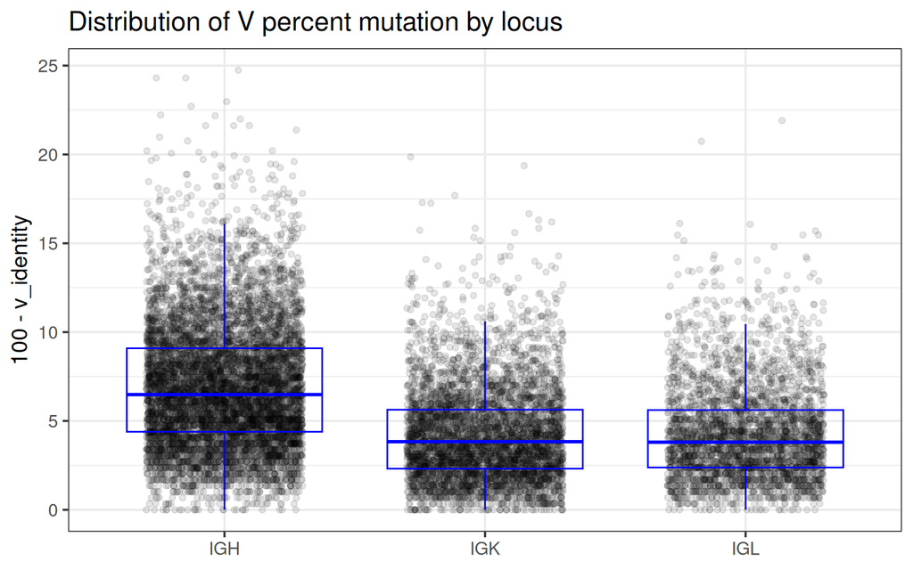

```r
out |>
    ggplot(aes(locus, 100 - v_identity)) +
    theme_bw(base_size=14) +
    geom_point(position = position_jitter(width = 0.3), alpha = 0.1) +
    geom_boxplot(color = "blue", fill = NA, outliers = FALSE, alpha = 0.3) +
    ggtitle("Distribution of V percent mutation by locus") +
    xlab(NULL)
```

Another common analysis is to investigate the distribution of germline genes (e.g., V genes). In this case, we typically stratify the analysis by locus or chain type.

```r
plot_gene_dist <- function(out, loc) {
    df_v_gene <- out |>
        filter(locus == loc) |>
        mutate(v_gene = sub("\\*[0-9]*", "", v_call)) |> # drop allele info
        group_by(v_gene) |>
        summarize(n = n(), .groups = "drop") |>
        mutate(frac = n / sum(n))
    df_v_gene |>
        ggplot(aes(frac, v_gene)) +
        theme_bw(base_size=13) +
        geom_col() +
        scale_x_continuous('Percent of sequences', labels = scales::percent) +
        ylab("Germline gene") +
        ggtitle(paste0(loc, "V gene prevalence"))
}
```

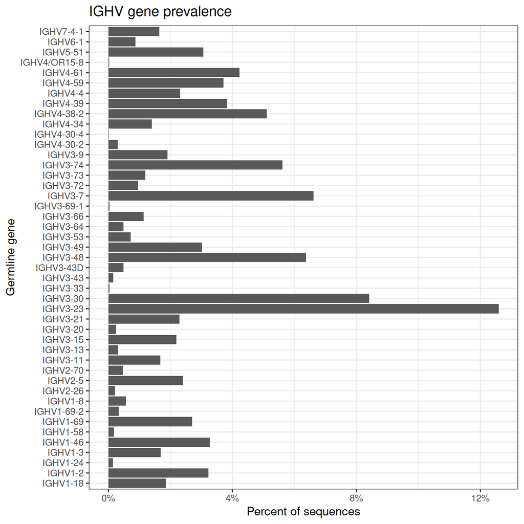

```r
plot_gene_dist(out, "IGH")
```

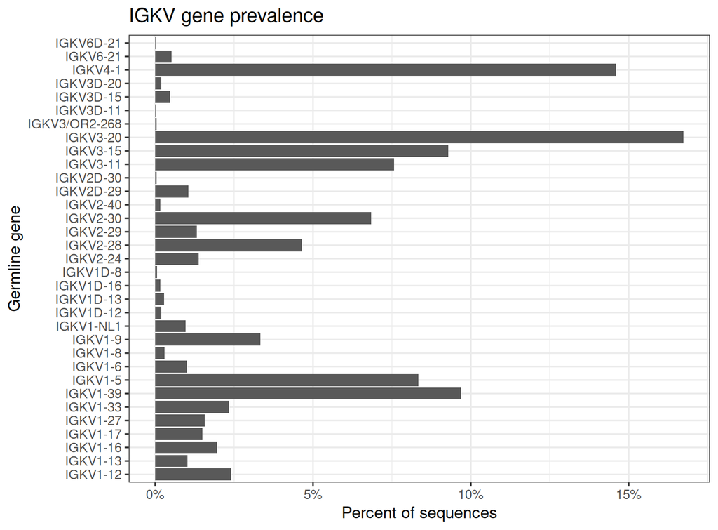

```r
plot_gene_dist(out, "IGK")
```

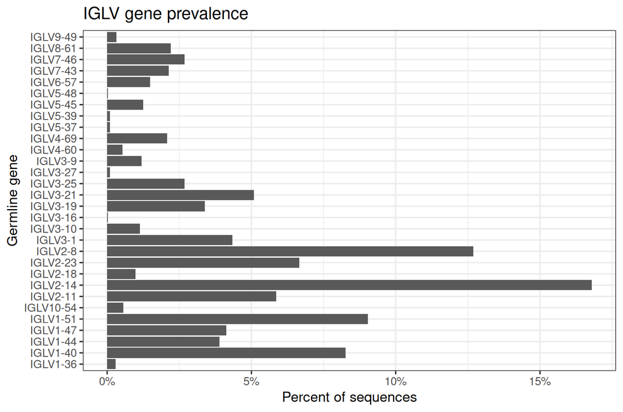

```r
plot_gene_dist(out, "IGL")
```

A third category of analysis focuses on CDR3 sequences, including their lengths and motifs, which are often visualized using sequence logo plots.

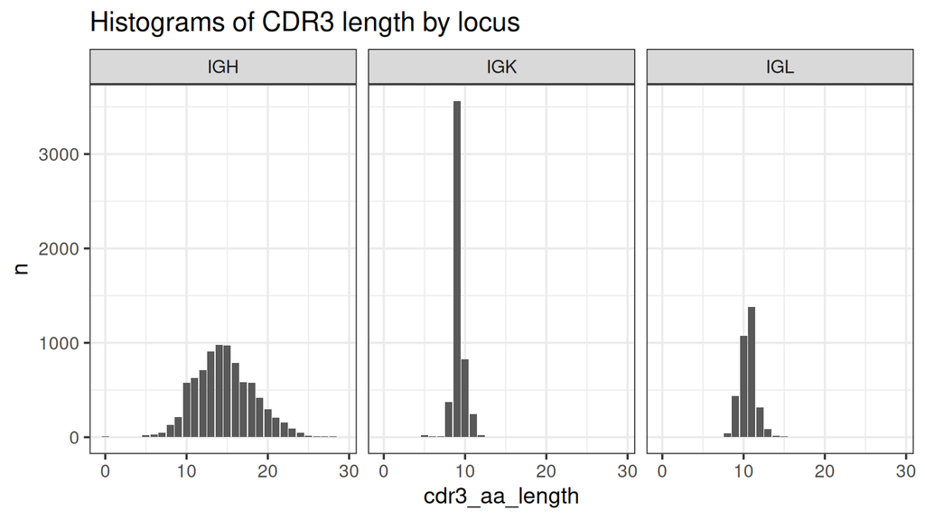

```r
out$cdr3_aa_length <- nchar(out$cdr3_aa)

out |>
    group_by(locus, cdr3_aa_length) |>
    summarize(n = n(), .groups = "drop") |>
    ggplot(aes(cdr3_aa_length, n)) +
    theme_bw(base_size=14) +
    facet_wrap(~locus) +
    geom_col() +
    ggtitle("Histograms of CDR3 length by locus")
```

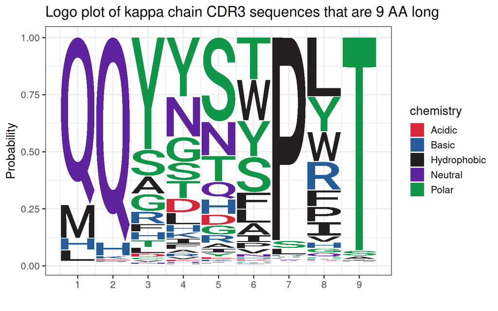

```r
out |>
    filter(locus == "IGK", cdr3_aa_length == 9) |>
    pull(cdr3_aa) |>
    ggseqlogo(method = "probability") +
    theme_bw(base_size=14) +
    ggtitle("Logo plot of kappa chain CDR3 sequences that are 9 AA long")
```

# 8 Future developments

At the moment, the *igblastr* package does not provide access to the full functionality of the IgBLAST software. In particular, the `igblastn()` function only supports the analysis of B-cell receptor (BCR) sequences. Also, the `igblastp` *standalone executable* included in IgBLAST has no counterpart in *igblastr*.

Some future developments include:

- Adding support for T-cell receptor (TCR) sequence analysis. This will require adding facilities to download and install TCR oriented germline databases, and to configure them for use with `igblastn(..., ig_seqtype="TCR")`.
- Implement `igblastp()`, a wrapper to the `igblastp` *standalone executable* included in IgBLAST for protein-level alignments.
- Facilities to retrieve germline databases from OGRDB, the AIRR Community’s Open Germline Reference Database.